# Simple Regression Model for Boston Housing Price

David Lowe

January 14, 2018

# Introduction

Credit: Template and study cases were adapted from blog posts made available by Dr. Jason Brownlee of Machine Learning Mastery (http://machinelearningmastery.com/).

For more information on this case study project, please consult Dr. Brownlee’s blog post at https://machinelearningmastery.com/regression-machine-learning-tutorial-weka/.

Dataset Used: Housing Values in Suburbs of Boston ML Model: Regression, numeric inputs Dataset Reference: https://archive.ics.uci.edu/ml/datasets/Housing

The purpose of this project is to analyze a dataset using various machine learning algorithms and to document the steps using a template. The project aims to touch on the following areas:

1. Document a regression predictive modeling problem end-to-end.
2. Explore data transfomration options for improving model performance
3. Explore algorithm tuning techniques for improving model performance

The template breaks down a predictive modeling project into 6 common tasks:

1. Define Problem
2. Summarize Data
3. Prepare Data
4. Evaluate Algorithms
5. Improve Accuracy or Results
6. Finalize Model and Present Results

## 1. Prepare Problem

### 1.a) Load libraries

```r
library(ggplot2)
library(mlbench)
library(caret)
library(corrplot)
```

### 1.b) Load dataset

Attach the BostonHousing dataset

```r
data(BostonHousing)
```

### 1.c) Split-out validation dataset

Create a training (variable name “dataset”) and a validation (variable name “validation”) dataset. Create a list of 80% of the rows in the original dataset we can use for training. Select 20% of the data for validation.

```r
set.seed(7)
validation_index <- createDataPartition(BostonHousing$medv, p=0.80, list=FALSE)
dataset <- BostonHousing[validation_index,]
dataset[,'chas'] <- as.numeric(dataset[,'chas'])
validation <- BostonHousing[-validation_index,]
validation[,'chas'] <- as.numeric(validation[,'chas'])
```

## 2. Summarize Data

To gain a better understanding of the data that we have on-hand, we will leverage a number of descriptive statistics and data visualization techniques. The plan is to use the results to consider new questions, review assumptions, and validate hypotheses that we can investigate later with specialized models.

### 2.a) Descriptive statistics

#### 2.a.i) Dimensions of the dataset.

```r
dim(dataset)
```

```
## [1] 407  14
```

#### 2.a.ii) Types of the attributes.

```r
sapply(dataset, class)
```

```
##      crim        zn     indus      chas       nox        rm       age
## "numeric" "numeric" "numeric" "numeric" "numeric" "numeric" "numeric"
##       dis       rad       tax   ptratio         b     lstat      medv
## "numeric" "numeric" "numeric" "numeric" "numeric" "numeric" "numeric"
```

#### 2.a.iii) Peek at the data itself.

```r
head(dataset)
```

```
##      crim   zn indus chas   nox    rm  age    dis rad tax ptratio      b
## 2 0.02731  0.0  7.07    1 0.469 6.421 78.9 4.9671   2 242    17.8 396.90
## 3 0.02729  0.0  7.07    1 0.469 7.185 61.1 4.9671   2 242    17.8 392.83
## 4 0.03237  0.0  2.18    1 0.458 6.998 45.8 6.0622   3 222    18.7 394.63
## 5 0.06905  0.0  2.18    1 0.458 7.147 54.2 6.0622   3 222    18.7 396.90
## 6 0.02985  0.0  2.18    1 0.458 6.430 58.7 6.0622   3 222    18.7 394.12
## 7 0.08829 12.5  7.87    1 0.524 6.012 66.6 5.5605   5 311    15.2 395.60
##   lstat medv
## 2  9.14 21.6
## 3  4.03 34.7
## 4  2.94 33.4
## 5  5.33 36.2
## 6  5.21 28.7
## 7 12.43 22.9
```

```r
tail(dataset)
```

```
##        crim zn indus chas   nox    rm  age    dis rad tax ptratio      b
## 499 0.23912  0  9.69    1 0.585 6.019 65.3 2.4091   6 391    19.2 396.90
## 500 0.17783  0  9.69    1 0.585 5.569 73.5 2.3999   6 391    19.2 395.77
## 501 0.22438  0  9.69    1 0.585 6.027 79.7 2.4982   6 391    19.2 396.90
## 502 0.06263  0 11.93    1 0.573 6.593 69.1 2.4786   1 273    21.0 391.99
## 503 0.04527  0 11.93    1 0.573 6.120 76.7 2.2875   1 273    21.0 396.90
## 504 0.06076  0 11.93    1 0.573 6.976 91.0 2.1675   1 273    21.0 396.90
##     lstat medv
## 499 12.92 21.2
## 500 15.10 17.5
## 501 14.33 16.8
## 502  9.67 22.4
## 503  9.08 20.6
## 504  5.64 23.9
```

#### 2.a.iv) Statistical summary of all attributes.

```r
summary(dataset)
```

```
##       crim                zn            indus            chas
##  Min.   : 0.00906   Min.   : 0.00   Min.   : 0.46   Min.   :1.000
##  1st Qu.: 0.08556   1st Qu.: 0.00   1st Qu.: 5.19   1st Qu.:1.000
##  Median : 0.28955   Median : 0.00   Median : 9.90   Median :1.000
##  Mean   : 3.58281   Mean   :10.57   Mean   :11.36   Mean   :1.076
##  3rd Qu.: 3.50464   3rd Qu.: 0.00   3rd Qu.:18.10   3rd Qu.:1.000
##  Max.   :88.97620   Max.   :95.00   Max.   :27.74   Max.   :2.000
##       nox               rm             age              dis
##  Min.   :0.3850   Min.   :3.863   Min.   :  2.90   Min.   : 1.130
##  1st Qu.:0.4530   1st Qu.:5.873   1st Qu.: 45.05   1st Qu.: 2.031
##  Median :0.5380   Median :6.185   Median : 77.70   Median : 3.216
##  Mean   :0.5577   Mean   :6.279   Mean   : 68.83   Mean   : 3.731
##  3rd Qu.:0.6310   3rd Qu.:6.611   3rd Qu.: 94.55   3rd Qu.: 5.100
##  Max.   :0.8710   Max.   :8.780   Max.   :100.00   Max.   :10.710
##       rad              tax           ptratio            b
##  Min.   : 1.000   Min.   :188.0   Min.   :12.60   Min.   :  0.32
##  1st Qu.: 4.000   1st Qu.:279.0   1st Qu.:17.40   1st Qu.:374.50
##  Median : 5.000   Median :330.0   Median :19.00   Median :391.13
##  Mean   : 9.464   Mean   :405.6   Mean   :18.49   Mean   :357.88
##  3rd Qu.:24.000   3rd Qu.:666.0   3rd Qu.:20.20   3rd Qu.:396.27
##  Max.   :24.000   Max.   :711.0   Max.   :22.00   Max.   :396.90
##      lstat             medv
##  Min.   : 1.730   Min.   : 5.00
##  1st Qu.: 6.895   1st Qu.:17.05
##  Median :11.500   Median :21.20
##  Mean   :12.827   Mean   :22.61
##  3rd Qu.:17.175   3rd Qu.:25.00
##  Max.   :37.970   Max.   :50.00
```

#### 2.a.v) Convert factor to numeric.

```r
dataset[,4] <- as.numeric(as.character(dataset[,4]))
```

#### 2.a.vi) summarize correlations between input variables.

```r
cor(dataset[,1:13])
```

```
##                crim          zn       indus        chas        nox
## crim     1.00000000 -0.19790631  0.40597009 -0.05713065  0.4232413
## zn      -0.19790631  1.00000000 -0.51895069 -0.04843477 -0.5058512
## indus    0.40597009 -0.51895069  1.00000000  0.08003629  0.7665481
## chas    -0.05713065 -0.04843477  0.08003629  1.00000000  0.1027366
## nox      0.42324132 -0.50585121  0.76654811  0.10273656  1.0000000
## rm      -0.21513269  0.28942883 -0.37673408  0.08252441 -0.2988506
## age      0.35438190 -0.57070265  0.65858310  0.10938121  0.7238371
## dis     -0.39050970  0.65618742 -0.72305885 -0.11142420 -0.7708680
## rad      0.64240501 -0.29952976  0.56774365 -0.00901245  0.5851676
## tax      0.60622608 -0.28791668  0.68070916 -0.02779018  0.6521787
## ptratio  0.28929828 -0.35341215  0.32920610 -0.13554380  0.1416616
## b       -0.30211854  0.16927489 -0.33597951  0.04724420 -0.3620791
## lstat    0.47537617 -0.39712686  0.59212718 -0.04569239  0.5819645
##                  rm        age        dis         rad         tax
## crim    -0.21513269  0.3543819 -0.3905097  0.64240501  0.60622608
## zn       0.28942883 -0.5707027  0.6561874 -0.29952976 -0.28791668
## indus   -0.37673408  0.6585831 -0.7230588  0.56774365  0.68070916
## chas     0.08252441  0.1093812 -0.1114242 -0.00901245 -0.02779018
## nox     -0.29885055  0.7238371 -0.7708680  0.58516760  0.65217875
## rm       1.00000000 -0.2325359  0.1952159 -0.19149122 -0.26794733
## age     -0.23253586  1.0000000 -0.7503321  0.45235421  0.50164657
## dis      0.19521590 -0.7503321  1.0000000 -0.49382744 -0.52649325
## rad     -0.19149122  0.4523542 -0.4938274  1.00000000  0.92137876
## tax     -0.26794733  0.5016466 -0.5264932  0.92137876  1.00000000
## ptratio -0.32000372  0.2564318 -0.2021897  0.45312318  0.44192428
## b        0.15539923 -0.2512574  0.2826819 -0.41033069 -0.41848779
## lstat   -0.62038075  0.5932128 -0.4957302  0.47306604  0.52339243
##            ptratio          b       lstat
## crim     0.2892983 -0.3021185  0.47537617
## zn      -0.3534121  0.1692749 -0.39712686
## indus    0.3292061 -0.3359795  0.59212718
## chas    -0.1355438  0.0472442 -0.04569239
## nox      0.1416616 -0.3620791  0.58196447
## rm      -0.3200037  0.1553992 -0.62038075
## age      0.2564318 -0.2512574  0.59321281
## dis     -0.2021897  0.2826819 -0.49573024
## rad      0.4531232 -0.4103307  0.47306604
## tax      0.4419243 -0.4184878  0.52339243
## ptratio  1.0000000 -0.1495283  0.35375936
## b       -0.1495283  1.0000000 -0.37661571
## lstat    0.3537594 -0.3766157  1.00000000
```

### 2.b) Data visualizations

#### 2.b.i) Univariate plots to better understand each attribute.

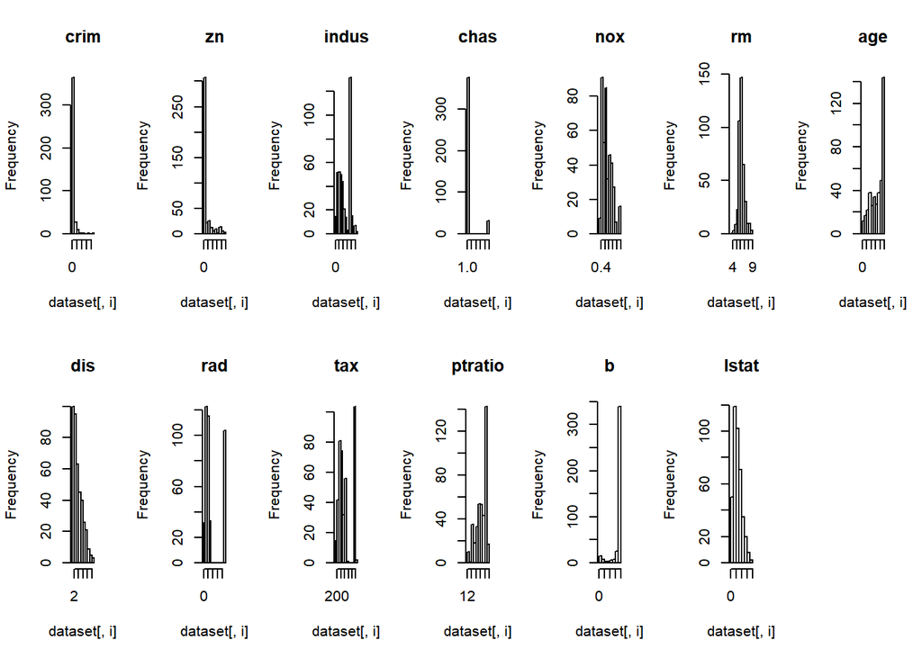

```r
# Histograms for each attribute
par(mfrow=c(2,7))
for(i in 1:13) {
    hist(dataset[,i], main=names(dataset)[i])
}
```

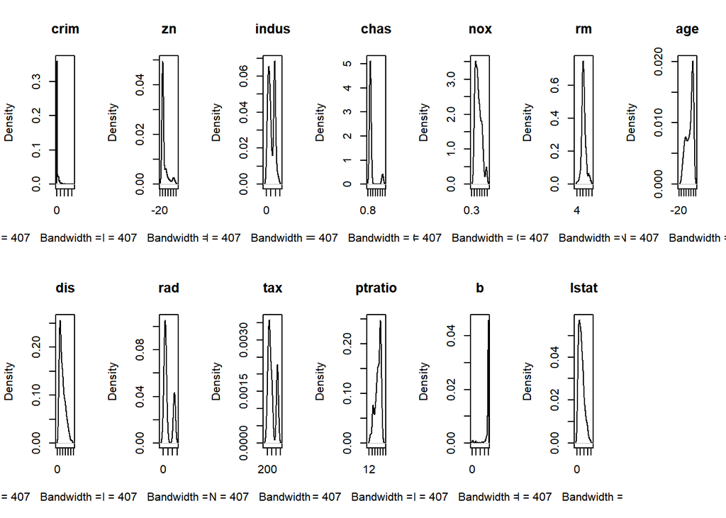

```r
# Density plot for each attribute
par(mfrow=c(2,7))
for(i in 1:13) {
    plot(density(dataset[,i]), main=names(dataset)[i])
}
```

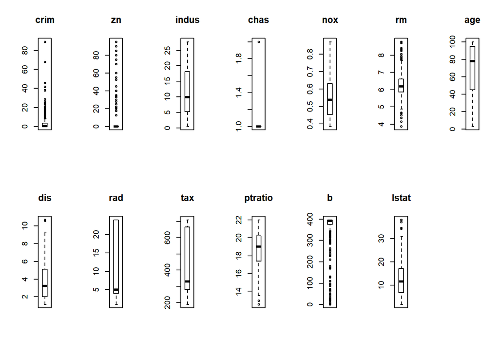

```r
# Boxplots for each attribute
par(mfrow=c(2,7))
for(i in 1:13) {
    boxplot(dataset[,i], main=names(dataset)[i])
}
```

#### 2.b.ii) Multivariate plots to better understand the relationships between attributes

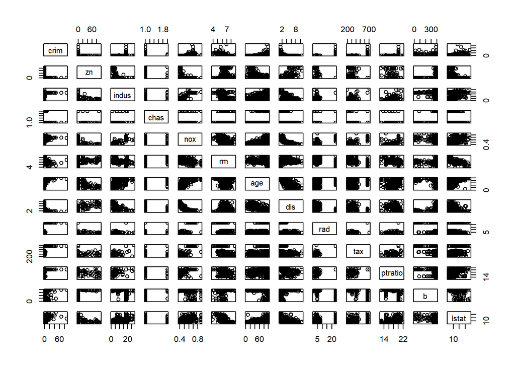

```r
# Scatterplot matrix
pairs(dataset[,1:13])
```

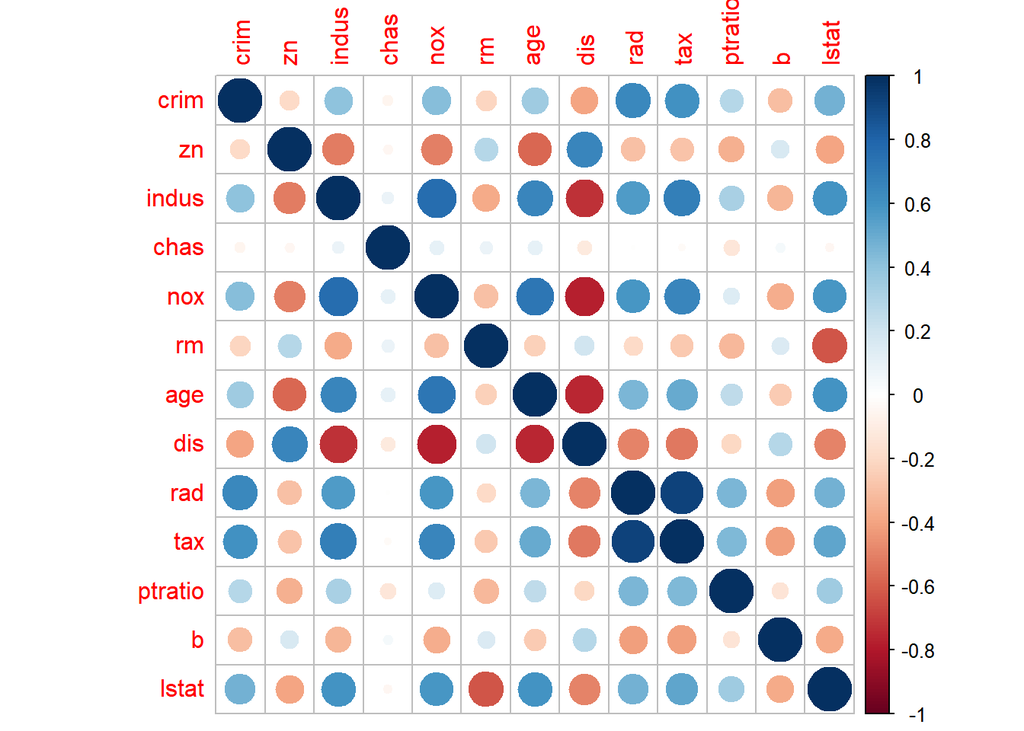

```r
# Correlation plot
correlations <- cor(dataset[,1:13])
corrplot(correlations, method="circle")
```

## 3. Prepare Data

Some dataset may require additional preparation activities that will best exposes the structure of the problem and the relationships between the input attributes and the output variable. Some data-prep tasks might include:

- Cleaning data by removing duplicates, marking missing values and even imputing missing values.
- Feature selection where redundant features may be removed.
- Data transforms where attributes are scaled or redistributed in order to best expose the structure of the problem later to learning algorithms.

### 3.a) Data Cleaning

### 3.b) Feature Selection

### 3.c) Data Transforms

## 4. Evaluate Algorithms

After the data-prep, we next work on finding a workable model by evaluating a subset of machine learning algorithms that are good at exploiting the structure of the dataset. The typical evaluation tasks include:

- Defining test options such as cross validation and the evaluation metric to use.
- Spot checking a suite of linear and nonlinear machine learning algorithms.
- Comparing the estimated accuracy of algorithms.

For this project, we will evaluate 6 different algorithms:

The random number seed is reset before each run to ensure that the evaluation of each algorithm is performed using the same data splits. It ensures the results are directly comparable.

### 4.a) Evaluate Algorithms: Baseline

```r
# Run algorithms using 10-fold cross validation
control <- trainControl(method="repeatedcv", number=10, repeats=3)
metric <- "RMSE"
# lm
set.seed(7)
fit.lm <- train(medv~., data=dataset, method="lm", metric=metric, preProc=c("center", "scale"), trControl=control)
# GLM
set.seed(7)
fit.glm <- train(medv~., data=dataset, method="glm", metric=metric, preProc=c("center", "scale"), trControl=control)
# GLMNET
set.seed(7)
fit.glmnet <- train(medv~., data=dataset, method="glmnet", metric=metric, preProc=c("center", "scale"), trControl=control)
# SVM
set.seed(7)
fit.svm <- train(medv~., data=dataset, method="svmRadial", metric=metric, preProc=c("center", "scale"), trControl=control)
# CART
set.seed(7)
grid <- expand.grid(.cp=c(0, 0.05, 0.1))
fit.cart <- train(medv~., data=dataset, method="rpart", metric=metric, tuneGrid=grid, preProc=c("center", "scale"), trControl=control)
# kNN
set.seed(7)
fit.knn <- train(medv~., data=dataset, method="knn", metric=metric, preProc=c("center", "scale"), trControl=control)
# Compare algorithms
results <- resamples(list(LM=fit.lm, GLM=fit.glm, GLMNET=fit.glmnet, SVM=fit.svm, CART=fit.cart, KNN=fit.knn))
summary(results)
```

```
##
## Call:
## summary.resamples(object = results)
##
## Models: LM, GLM, GLMNET, SVM, CART, KNN
## Number of resamples: 30
##
## MAE
##            Min.  1st Qu.   Median     Mean  3rd Qu.     Max. NA's
## LM     2.275798 3.105566 3.476184 3.501075 3.988069 4.806931    0
## GLM    2.275798 3.105566 3.476184 3.501075 3.988069 4.806931    0
## GLMNET 2.249747 3.054908 3.436463 3.472943 4.002405 4.819706    0
## SVM    1.636837 2.083861 2.395264 2.412779 2.615126 3.597281    0
## CART   2.043357 2.509889 2.875049 2.931782 3.294371 4.707060    0
## KNN    2.036111 2.675617 3.023173 3.026927 3.346350 4.663144    0
##
## RMSE
##            Min.  1st Qu.   Median     Mean  3rd Qu.     Max. NA's
## LM     2.945061 4.120871 4.590366 4.946754 5.622836 7.966565    0
## GLM    2.945061 4.120871 4.590366 4.946754 5.622836 7.966565    0
## GLMNET 2.900783 4.135902 4.580667 4.944112 5.641409 8.044256    0
## SVM    2.164717 2.979377 3.736229 3.980410 4.723911 7.251589    0
## CART   2.519930 3.428198 4.294325 4.372673 5.169167 7.856569    0
## KNN    3.100655 3.690470 4.579753 4.687796 5.442480 8.369137    0
##
## Rsquared
##             Min.   1st Qu.    Median      Mean   3rd Qu.      Max. NA's
## LM     0.4723270 0.6698297 0.7479362 0.7323877 0.8184113 0.8830690    0
## GLM    0.4723270 0.6698297 0.7479362 0.7323877 0.8184113 0.8830690    0
## GLMNET 0.4602065 0.6704187 0.7505348 0.7325322 0.8182185 0.8904240    0
## SVM    0.5715369 0.7795105 0.8572078 0.8249574 0.8968088 0.9474025    0
## CART   0.4803188 0.7100007 0.7991753 0.7837238 0.8504914 0.9358565    0
## KNN    0.4295926 0.7514504 0.7924037 0.7746890 0.8521054 0.9166735    0
```

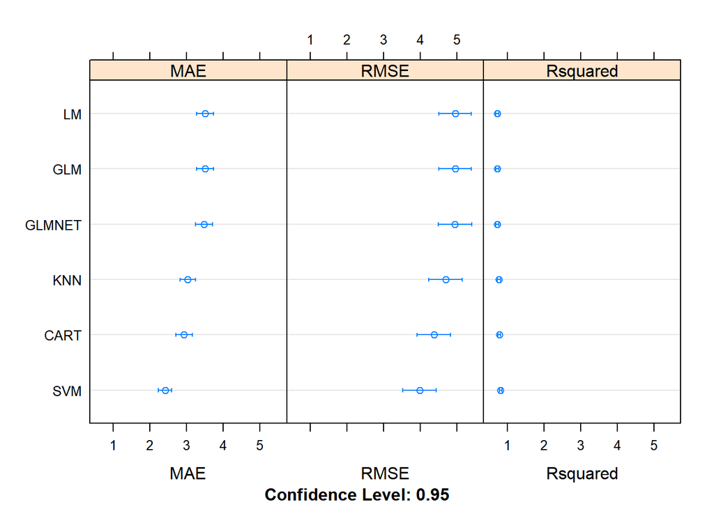

```r
dotplot(results)
```

### 4.b) Evaluate Algorithms: Feature Selection

```r
# remove correlated attributes
# find attributes that are highly corrected
set.seed(7)
cutoff <- 0.70
correlations <- cor(dataset[,1:13])
highlyCorrelated <- findCorrelation(correlations, cutoff=cutoff)
for (value in highlyCorrelated) {
    print(names(dataset)[value])
}
```

```
## [1] "indus"
## [1] "nox"
## [1] "tax"
## [1] "dis"
```

```r
# create a new dataset without highly corrected features
dataset_features <- dataset[,-highlyCorrelated]
dim(dataset_features)
```

```
## [1] 407  10
```

```r
# Run algorithms using 10-fold cross validation
control <- trainControl(method="repeatedcv", number=10, repeats=3)
metric <- "RMSE"
# lm
set.seed(7)
fit.lm <- train(medv~., data=dataset_features, method="lm", metric=metric, preProc=c("center", "scale"), trControl=control)
# GLM
set.seed(7)
fit.glm <- train(medv~., data=dataset_features, method="glm", metric=metric, preProc=c("center", "scale"), trControl=control)
# GLMNET
set.seed(7)
fit.glmnet <- train(medv~., data=dataset_features, method="glmnet", metric=metric, preProc=c("center", "scale"), trControl=control)
# SVM
set.seed(7)
fit.svm <- train(medv~., data=dataset_features, method="svmRadial", metric=metric, preProc=c("center", "scale"), trControl=control)
# CART
set.seed(7)
grid <- expand.grid(.cp=c(0, 0.05, 0.1))
fit.cart <- train(medv~., data=dataset_features, method="rpart", metric=metric, tuneGrid=grid, preProc=c("center", "scale"), trControl=control)
# kNN
set.seed(7)
fit.knn <- train(medv~., data=dataset_features, method="knn", metric=metric, preProc=c("center", "scale"), trControl=control)
# Compare algorithms
feature_results <- resamples(list(LM=fit.lm, GLM=fit.glm, GLMNET=fit.glmnet, SVM=fit.svm, CART=fit.cart, KNN=fit.knn))
summary(feature_results)
```

```
##
## Call:
## summary.resamples(object = feature_results)
##
## Models: LM, GLM, GLMNET, SVM, CART, KNN
## Number of resamples: 30
##
## MAE
##            Min.  1st Qu.   Median     Mean  3rd Qu.     Max. NA's
## LM     2.581207 3.245913 3.612843 3.687229 4.026392 5.148788    0
## GLM    2.581207 3.245913 3.612843 3.687229 4.026392 5.148788    0
## GLMNET 2.457098 3.263388 3.612401 3.655058 3.866505 5.154045    0
## SVM    1.701193 2.352631 2.756603 2.692734 3.070049 3.998602    0
## CART   2.244475 2.512546 2.867973 2.977266 3.153672 5.091982    0
## KNN    2.175500 2.661646 3.047287 3.014089 3.331220 4.500488    0
##
## RMSE
##            Min.  1st Qu.   Median     Mean  3rd Qu.     Max. NA's
## LM     3.240150 4.366222 4.991584 5.285267 5.903958 8.517783    0
## GLM    3.240150 4.366222 4.991584 5.285267 5.903958 8.517783    0
## GLMNET 2.958713 4.436144 4.983526 5.247147 5.986477 8.480235    0
## SVM    2.283553 3.333524 4.041464 4.375623 5.496401 7.577551    0
## CART   2.897772 3.492845 4.118793 4.395251 4.617383 8.171875    0
## KNN    3.144079 3.908360 4.546349 4.662776 5.571105 7.883717    0
##
## Rsquared
##             Min.   1st Qu.    Median      Mean   3rd Qu.      Max. NA's
## LM     0.4129148 0.6386145 0.7038130 0.6979964 0.7878433 0.8720645    0
## GLM    0.4129148 0.6386145 0.7038130 0.6979964 0.7878433 0.8720645    0
## GLMNET 0.3986900 0.6329603 0.7241796 0.7057707 0.8139213 0.8833758    0
## SVM    0.5272147 0.6978457 0.8297009 0.7824937 0.8750123 0.9259037    0
## CART   0.4651813 0.7218025 0.8167862 0.7782884 0.8608693 0.9123469    0
## KNN    0.4870866 0.6954455 0.7682838 0.7630308 0.8542543 0.8962957    0
```

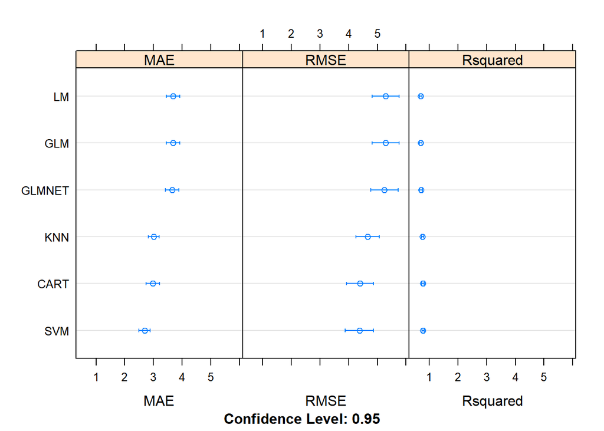

```r
dotplot(feature_results)
```

## 5. Improve Accuracy

After we achieve a short list of machine learning algorithms with good level of accuracy, we can leverage ways to improve the accuracy of the models:

- Search for a combination of parameters for each algorithm using caret that yields the best results.
- Combine the prediction of multiple models into an ensemble prediction using standalone algorithms or the caretEnsemble package.

For this project, we look at how tuning the SVM algoritm could be helpful for our final model. For future project, we will also look at the ensemble methods for optimizing the model.

### 5.a) Algorithm Tuning

```r
# look at parameters
print(fit.svm)
```

```
## Support Vector Machines with Radial Basis Function Kernel
##
## 407 samples
##   9 predictor
##
## Pre-processing: centered (9), scaled (9)
## Resampling: Cross-Validated (10 fold, repeated 3 times)
## Summary of sample sizes: 366, 367, 366, 367, 365, 367, ...
## Resampling results across tuning parameters:
##
##   C     RMSE      Rsquared   MAE
##   0.25  5.046789  0.7381375  3.019142
##   0.50  4.642732  0.7664493  2.811846
##   1.00  4.375623  0.7824937  2.692734
##
## Tuning parameter 'sigma' was held constant at a value of 0.1607243
## RMSE was used to select the optimal model using the smallest value.
## The final values used for the model were sigma = 0.1607243 and C = 1.
```

```r
# tune SVM sigma and C parametres
control <- trainControl(method="repeatedcv", number=10, repeats=3)
metric <- "RMSE"
set.seed(7)
grid <- expand.grid(.sigma=c(0.025, 0.05, 0.1, 0.15), .C=seq(1, 10, by=1))
fit.svm <- train(medv~., data=dataset, method="svmRadial", metric=metric, tuneGrid=grid, preProc=c("center", "scale"), trControl=control)
print(fit.svm)
```

```
## Support Vector Machines with Radial Basis Function Kernel
##
## 407 samples
##  13 predictor
##
## Pre-processing: centered (13), scaled (13)
## Resampling: Cross-Validated (10 fold, repeated 3 times)
## Summary of sample sizes: 366, 367, 366, 367, 365, 367, ...
## Resampling results across tuning parameters:
##
##   sigma  C   RMSE      Rsquared   MAE
##   0.025   1  3.980260  0.8226672  2.431378
##   0.025   2  3.781997  0.8359958  2.314814
##   0.025   3  3.716893  0.8405077  2.281515
##   0.025   4  3.686209  0.8424269  2.274672
##   0.025   5  3.672046  0.8433005  2.269722
##   0.025   6  3.667407  0.8432887  2.266854
##   0.025   7  3.648504  0.8446569  2.261141
##   0.025   8  3.628969  0.8464505  2.254838
##   0.025   9  3.617251  0.8475696  2.254309
##   0.025  10  3.605765  0.8487520  2.255153
##   0.050   1  3.924961  0.8277382  2.385241
##   0.050   2  3.708654  0.8415364  2.290586
##   0.050   3  3.623573  0.8471563  2.270134
##   0.050   4  3.532299  0.8541607  2.249795
##   0.050   5  3.448973  0.8601862  2.233697
##   0.050   6  3.375854  0.8653196  2.216973
##   0.050   7  3.328384  0.8684962  2.205407
##   0.050   8  3.290491  0.8710913  2.194805
##   0.050   9  3.259630  0.8732176  2.184576
##   0.050  10  3.236860  0.8749106  2.179578
##   0.100   1  3.996193  0.8236371  2.420706
##   0.100   2  3.646719  0.8450931  2.327119
##   0.100   3  3.462625  0.8565247  2.246721
##   0.100   4  3.387572  0.8615393  2.212897
##   0.100   5  3.365004  0.8630589  2.212674
##   0.100   6  3.359391  0.8635794  2.224123
##   0.100   7  3.351425  0.8642959  2.227412
##   0.100   8  3.348502  0.8645729  2.232179
##   0.100   9  3.345200  0.8649189  2.234094
##   0.100  10  3.345735  0.8649873  2.237457
##   0.150   1  4.158285  0.8093427  2.489308
##   0.150   2  3.727560  0.8367397  2.362192
##   0.150   3  3.596788  0.8436202  2.310866
##   0.150   4  3.575540  0.8454478  2.314217
##   0.150   5  3.566290  0.8462528  2.320091
##   0.150   6  3.547700  0.8475303  2.315214
##   0.150   7  3.549047  0.8470441  2.318568
##   0.150   8  3.555137  0.8461624  2.325369
##   0.150   9  3.563767  0.8451763  2.333318
##   0.150  10  3.570841  0.8444028  2.341640
##
## RMSE was used to select the optimal model using the smallest value.
## The final values used for the model were sigma = 0.05 and C = 10.
```

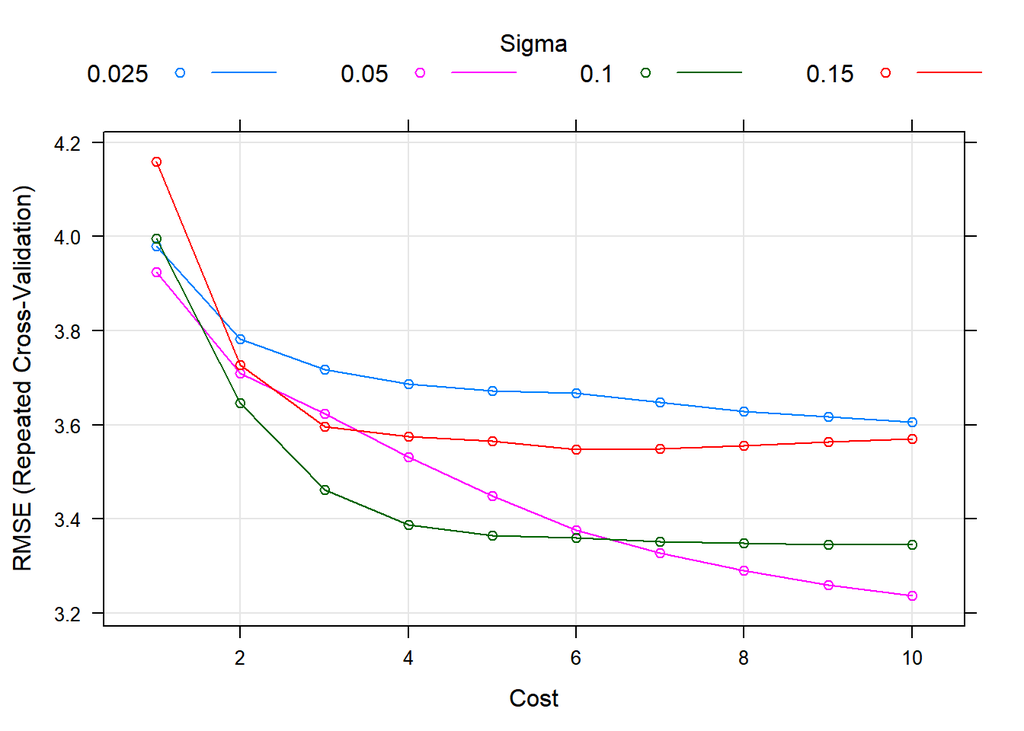

```r
plot(fit.svm)
```

### 5.b) Ensemble Methods

## 6. Finalize Model

Once we have narrow down to a model that we believe can make accurate predictions on unseen data, we are ready to finalize it. Finalizing a model may involve sub-tasks such as:

- Using an optimal model tuned to make predictions on unseen data.
- Creating a standalone model using the tuned parameters
- Saving an optimal model to file for later use.

### 6.a) Predictions on validation dataset

```r
valY <- validation[,14]
predictions <- predict(fit.svm, newdata=validation)
print(RMSE(predictions, valY))
```

```
## [1] 2.880451
```

```r
print(R2(predictions, valY))
```

```
## [1] 0.8856234
```

### 6.b) Create standalone model on entire training dataset

### 6.c) Save model for later use